# Prediction of AIRBNB prices in Rome

Girolami Mattia

2024-07-24

# Abstract

The goal of this project is to predict Airbnb prices in the city of Rome and identify the most relevant features for determining these prices.

The data was obtained from **[Inside Airbnb]**(https://insideairbnb.com/rome/), a free platform that allows for the download of Airbnb data for the desired city.

# Features

| id | listing_url | scrape_id | last_scraped | source | name | picture_url | host_id | host_url | host_name |
| --- | --- | --- | --- | --- | --- | --- | --- | --- | --- |
| 7.310316e+17 | https://www.airbnb.com/rooms/731031555912825824 | 2.024062e+13 | 2024-06-15 | city scrape | Appartamento accogliente a Barberini - L’Aurora | https://a0.muscache.com/pictures/6997c012-c208-4088-9fbb-768354317ad2.jpg | 482347258 | https://www.airbnb.com/users/show/482347258 | Angela |
| 7.373199e+17 | https://www.airbnb.com/rooms/737319884245855140 | 2.024062e+13 | 2024-06-15 | city scrape | Elical Exclusive Private Suites Quadruple Room. | https://a0.muscache.com/pictures/miso/Hosting-737280120975061019/original/f4c1e820-2875-4229-9540-eb165c6f766f.jpeg | 196775325 | https://www.airbnb.com/users/show/196775325 | Giuseppe |
| 1.050844e+18 | https://www.airbnb.com/rooms/1050843717778750989 | 2.024062e+13 | 2024-06-15 | city scrape | Historical Loft with view in city center! | https://a0.muscache.com/pictures/miso/Hosting-1050843717778750989/original/253e6af1-a3eb-43dd-895e-816309926f74.jpeg | 8757681 | https://www.airbnb.com/users/show/8757681 | Roger & Team |
| 9.927449e+17 | https://www.airbnb.com/rooms/992744912505056648 | 2.024062e+13 | 2024-06-15 | city scrape | BDC - Termini Luxury Studio | https://a0.muscache.com/pictures/prohost-api/Hosting-992744912505056648/original/8f8c13db-f234-42a5-b664-3cda314f97dd.jpeg | 486878749 | https://www.airbnb.com/users/show/486878749 | Stefano |
| 1.107075e+18 | https://www.airbnb.com/rooms/1107075395952219186 | 2.024062e+13 | 2024-06-16 | city scrape | Exclusive apartment near the Vatican Museums | https://a0.muscache.com/pictures/miso/Hosting-1107075395952219186/original/0d4fb910-7e7e-4d00-b223-31816307d8df.jpeg | 562146402 | https://www.airbnb.com/users/show/562146402 | Susanna |
| 6.871623e+06 | https://www.airbnb.com/rooms/6871623 | 2.024062e+13 | 2024-06-15 | city scrape | Charming Pantheon Apt in the heart of Rome! | https://a0.muscache.com/pictures/miso/Hosting-6871623/original/037a0a94-b00d-42e7-a7be-ea7234348197.jpeg | 29312074 | https://www.airbnb.com/users/show/29312074 | Lavinia Francesca |
| 4.079926e+06 | https://www.airbnb.com/rooms/4079926 | 2.024062e+13 | 2024-06-15 | city scrape | Single house near metro A with rooftop | https://a0.muscache.com/pictures/hosting/Hosting-U3RheVN1cHBseUxpc3Rpbmc6NDA3OTkyNg%3D%3D/original/6e273cdc-6a9f-40f2-81d6-018b582c4e67.png | 21162337 | https://www.airbnb.com/users/show/21162337 | Claudia |
| 1.015849e+18 | https://www.airbnb.com/rooms/1015848609968012561 | 2.024062e+13 | 2024-06-15 | city scrape | Le Triplette Orange Room | https://a0.muscache.com/pictures/miso/Hosting-1015848609968012561/original/9e824bb4-1863-4bf8-a426-018ab4eb48a5.jpeg | 496143979 | https://www.airbnb.com/users/show/496143979 | Nino |
| 8.209118e+06 | https://www.airbnb.com/rooms/8209118 | 2.024062e+13 | 2024-06-15 | city scrape | WHERE THE ROMANS…THE COLOSSEUM (sanitized ozone) | https://a0.muscache.com/pictures/dc727761-14bc-4825-b482-8dc3c7d99f56.jpg | 1180196 | https://www.airbnb.com/users/show/1180196 | Andrea |
| 1.128272e+18 | https://www.airbnb.com/rooms/1128272313860752469 | 2.024062e+13 | 2024-06-15 | city scrape | Rome Nest at Campo De’ Fiori/Navona | https://a0.muscache.com/pictures/hosting/Hosting-1128272313860752469/original/0e9fe6a6-3b2c-4a00-b708-eb04a2cb0d8f.jpeg | 49060462 | https://www.airbnb.com/users/show/49060462 | Vincenza |

```
## The dataset has  72  columns.
```

As observed, the dataset contains a large number of features, most of which are descriptive in nature, such as the URL, scrape ID, etc. To facilitate data analysis, we will focus exclusively on the features that are most pertinent to our analysis. These are:

- *Price*: meant as price($) per night, our target variable
- *Accommodates*: the number of person the Airbnb can host
- *Beds*: the number of beds in the Airbnb
- *Room Type* : the type of accommodation (e.g. private room, hotel, entire room/apt)
- *Latitude* and *Longitude*: the coordinates of the Airbnb
- *Availability365* : the number of days an Airbnb is booked in a year
- *Host Acceptance* and *Response rate*: how much an host is likely to answer the messages and accept people
- *Number of reviews* : total number of reviews
- *Review scores*:
  - *Communication* : a score indicating how effective the communication with the host was
  - *Location* : a score indicating the comfort of the accommodation location
  - *Cleanliness* : a score indicating the cleanliness of the accommodation
- *Neighborhood* : The neighborhood of the stay
- *Property Type* : The type of rental unit (entire condo, entire rental unit etc.)

# Feature Engineering

Before proceeding with the analysis, feature engineering is required because the columns contain values that cannot be processed in their current format.

To make the latitude and longitude features relevant, I decided to create new features. Firstly, I selected four well-known points of interest in the city of Rome: the **Colosseum**, the **Vatican**, **Trastevere**, and **Piazza di Spagna**. After selecting these points, I obtained their coordinates (*LAT, LONG*) and calculated the Haversine distance from each Airbnb listing to the chosen points of interest, adding the reciprocal of the distance as a new feature for each field in order to have higher scores for places near the POI and lower scores for those furthest away .

```r
calculate_distance <- function(lat1, lon1, lat2, lon2) {
  distHaversine(c(lon1, lat1), c(lon2, lat2)) / 1000  # Distance in kilometers
}
```

```r
# Points of Interest (POIs)
pois <- data.frame(
  name = c("Colosseo", "Vaticano", "Trastevere", "Spagna"),
  latitude = c(41.890251, 41.907989638871555, 41.891826, 41.9057843812776),
  longitude = c(12.492373, 12.455535072091655, 12.469973, 12.482191227341854)
)
```

```r
for (i in 1:nrow(pois)) {
  poi_name <- tolower(pois$name[i])
  data_clean[[paste0("distance_from_", poi_name)]] <- mapply(
    calculate_distance,
    data_clean$latitude,
    data_clean$longitude,
    MoreArgs = list(lat2 = pois$latitude[i], lon2 = pois$longitude[i])
  )
}
```

The remaining features were manipulated as follows:

- Rows with null values were removed.
- The price feature was converted to a numeric format by removing the ‘$’ symbol.
- Host response rate and host acceptance rate were converted from percentage strings (xx%) to numeric format between 0 and 1.
- The beds feature was binarized, assigning a value of 1 to locations with 1 or 2 beds and 0 otherwise.
- The accommodates feature was binarized into three new binary features: one for 1 or 2 guests (for solo travelers or couples), one for 3 to 6 guests (potentially for families or small groups), and one for 7 to 15 guests (large groups).
- The number of reviews feature was logarithmically transformed to mitigate the effect of outliers (locations with significantly more reviews compared to others).
- Availability_365, review scores for communication, location, and cleanliness were normalized.

```r
tosave_2 <- c("price", "host_response_rate", "host_acceptance_rate",
              "accommodates_1_2", "accommodates_3_6", "accommodates_7_15",
              "max2_beds", "latitude", "longitude",
              "availability_365", "number_of_reviews",
              "review_scores_cleanliness", "review_scores_communication", "review_scores_location",
              "distance_from_colosseo", "distance_from_vaticano",
              "distance_from_trastevere", "distance_from_spagna", "room_type", "neighbourhood_cleansed", 'property_type')

data_clean <- data_clean %>%
  dplyr::select(tosave_2) %>%
  mutate(
    distance_from_colosseo = 1 / distance_from_colosseo,
    distance_from_vaticano = 1 / distance_from_vaticano,
    distance_from_trastevere = 1 / distance_from_trastevere,
    distance_from_spagna = 1 / distance_from_spagna,
  )
```

After the preprocessing part these are the results.

```
## Number of null values: 0
```

Sample of the Data

| price | host_response_rate | host_acceptance_rate | accommodates_1_2 | accommodates_3_6 | accommodates_7_15 | max2_beds | latitude | longitude | availability_365 |
| --- | --- | --- | --- | --- | --- | --- | --- | --- | --- |
| 176 | 1 | 1.00 | 0 | 1 | 0 | 1 | 41.90803 | 12.48867 | 0.2739726 |
| 396 | 1 | 0.98 | 0 | 1 | 0 | 0 | 41.90017 | 12.48428 | 0.3369863 |
| 219 | 1 | 1.00 | 0 | 1 | 0 | 1 | 41.89609 | 12.47206 | 0.9424658 |
| 136 | 1 | 1.00 | 1 | 0 | 0 | 1 | 41.89801 | 12.50433 | 0.9205479 |
| 122 | 1 | 0.96 | 0 | 1 | 0 | 1 | 41.90568 | 12.44609 | 0.3095890 |
| 187 | 1 | 1.00 | 0 | 1 | 0 | 1 | 41.89693 | 12.47667 | 0.6273973 |
| 75 | 1 | 0.99 | 1 | 0 | 0 | 1 | 41.90546 | 12.42126 | 0.2054795 |
| 135 | 1 | 1.00 | 1 | 0 | 0 | 1 | 41.88037 | 12.46639 | 0.1643836 |
| 150 | 1 | 0.99 | 0 | 1 | 0 | 1 | 41.89096 | 12.49447 | 0.3835616 |
| 124 | 1 | 1.00 | 1 | 0 | 0 | 1 | 41.89596 | 12.47172 | 0.6739726 |

```r
summary(data_clean)
```

```
##      price        host_response_rate host_acceptance_rate accommodates_1_2
##  Min.   :  14.0   Min.   :0.0000     Min.   :0.0000       Min.   :0.0000
##  1st Qu.: 100.0   1st Qu.:1.0000     1st Qu.:0.9700       1st Qu.:0.0000
##  Median : 141.0   Median :1.0000     Median :1.0000       Median :0.0000
##  Mean   : 185.8   Mean   :0.9717     Mean   :0.9284       Mean   :0.3393
##  3rd Qu.: 202.0   3rd Qu.:1.0000     3rd Qu.:1.0000       3rd Qu.:1.0000
##  Max.   :9999.0   Max.   :1.0000     Max.   :1.0000       Max.   :1.0000
##  accommodates_3_6 accommodates_7_15   max2_beds        latitude
##  Min.   :0.0000   Min.   :0.00000   Min.   :0.000   Min.   :41.72
##  1st Qu.:0.0000   1st Qu.:0.00000   1st Qu.:0.000   1st Qu.:41.89
##  Median :1.0000   Median :0.00000   Median :1.000   Median :41.90
##  Mean   :0.6037   Mean   :0.05669   Mean   :0.731   Mean   :41.89
##  3rd Qu.:1.0000   3rd Qu.:0.00000   3rd Qu.:1.000   3rd Qu.:41.91
##  Max.   :1.0000   Max.   :1.00000   Max.   :1.000   Max.   :42.12
##    longitude     availability_365 number_of_reviews review_scores_cleanliness
##  Min.   :12.25   Min.   :0.0000   Min.   :0.6931    Min.   :0.0000
##  1st Qu.:12.46   1st Qu.:0.3397   1st Qu.:2.1972    1st Qu.:0.9200
##  Median :12.48   Median :0.5918   Median :3.3673    Median :0.9650
##  Mean   :12.48   Mean   :0.5597   Mean   :3.3134    Mean   :0.9435
##  3rd Qu.:12.50   3rd Qu.:0.7973   3rd Qu.:4.4773    3rd Qu.:0.9950
##  Max.   :12.73   Max.   :1.0000   Max.   :6.8134    Max.   :1.0000
##  review_scores_communication review_scores_location distance_from_colosseo
##  Min.   :0.0000              Min.   :0.2500         Min.   : 0.03428
##  1st Qu.:0.9550              1st Qu.:0.9100         1st Qu.: 0.24028
##  Median :0.9850              Median :0.9575         Median : 0.37465
##  Mean   :0.9654              Mean   :0.9381         Mean   : 0.51739
##  3rd Qu.:1.0000              3rd Qu.:0.9900         3rd Qu.: 0.57263
##  Max.   :1.0000              Max.   :1.0000         Max.   :19.22466
##  distance_from_vaticano distance_from_trastevere distance_from_spagna
##  Min.   : 0.0384        Min.   : 0.03549         Min.   : 0.0367
##  1st Qu.: 0.1894        1st Qu.: 0.24311         1st Qu.: 0.2334
##  Median : 0.2886        Median : 0.38300         Median : 0.3873
##  Mean   : 0.5794        Mean   : 0.67440         Mean   : 0.5582
##  3rd Qu.: 0.5259        3rd Qu.: 0.59535         3rd Qu.: 0.6047
##  Max.   :27.3780        Max.   :32.72617         Max.   :24.3656
##   room_type         neighbourhood_cleansed property_type
##  Length:7267        Length:7267            Length:7267
##  Class :character   Class :character       Class :character
##  Mode  :character   Mode  :character       Mode  :character
##
##
##
```

# Exploratory Data Analysis

## Maps visualization

To further enhance our data analysis, I decided to visualize the locations of the Airbnb listings from the dataset by plotting them on a map. This allows us to observe areas with higher concentrations of Airbnb listings and to evaluate whether the features previously added based on the Points of Interest are “reliable” in any way.

[interactive chart not shown]

As hypothesized, we can observe that the areas with the highest concentration of Airbnb listings are indeed the historic center, particularly the region between the Colosseum and Termini Station, the area around Piazza di Spagna/Via del Corso, Trastevere, and finally the Vatican along with the adjacent Prati neighborhood.

To provide an additional useful visualization of our data, the map of Rome is displayed below as before. However, this time, the map highlights areas with more expensive Airbnb listings. Once again, the aforementioned points of interest are prominent, with particular emphasis on the areas surrounding Piazza Navona.

[interactive chart not shown]

## Features Analysis

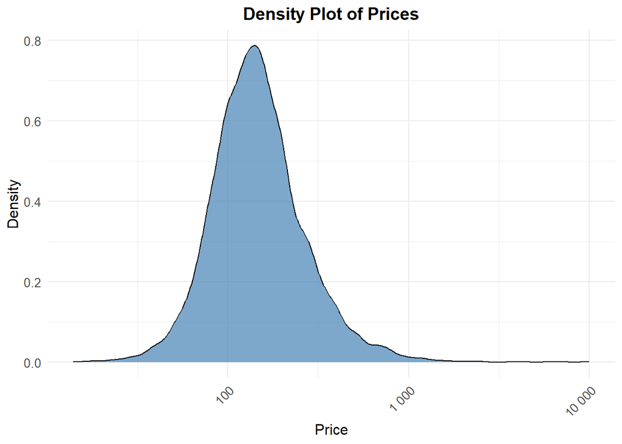

```
## The average price of the AirBnbs in Rome is  185.76 $
```

To analyze how Airbnb prices are distributed by neighborhood, we first examine the distribution of listings across different neighborhoods. As anticipated, the neighborhood with the highest number of listings is **Centro Storico**, with over 3,000 more properties compared to the second most populated neighborhood, **San Giovanni**.

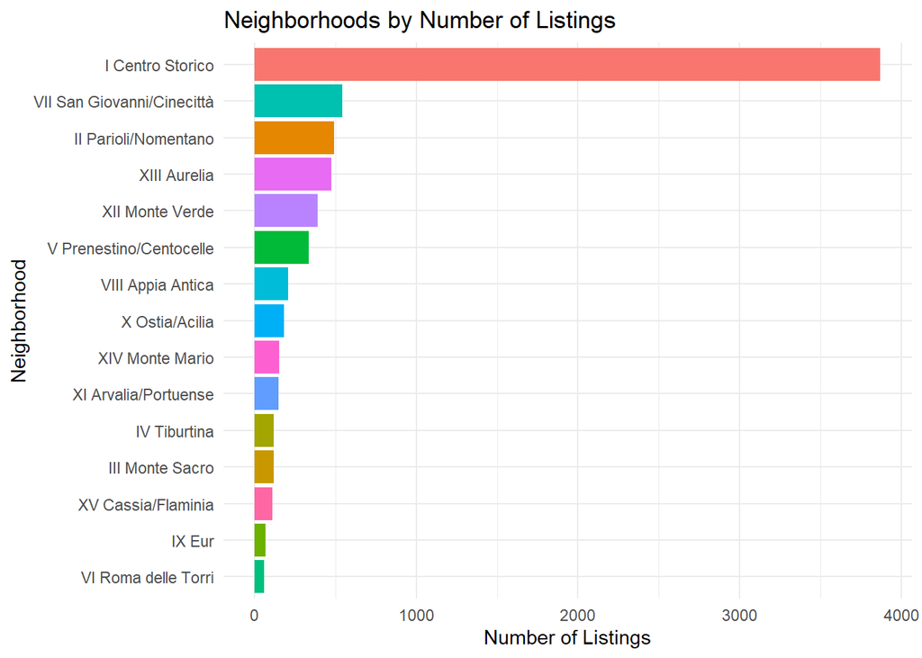

The following chart illustrates how prices vary by neighborhood, using the top 5 neighborhoods by number of listings as a sample. Above the box for each neighborhood, the average price of Airbnb listings in that area is indicated.

We can observe that Centro Storico has a significantly higher average price compared to the overall average, followed by Aurelia. Among the top 5 neighborhoods, San Giovanni has the lowest average prices.

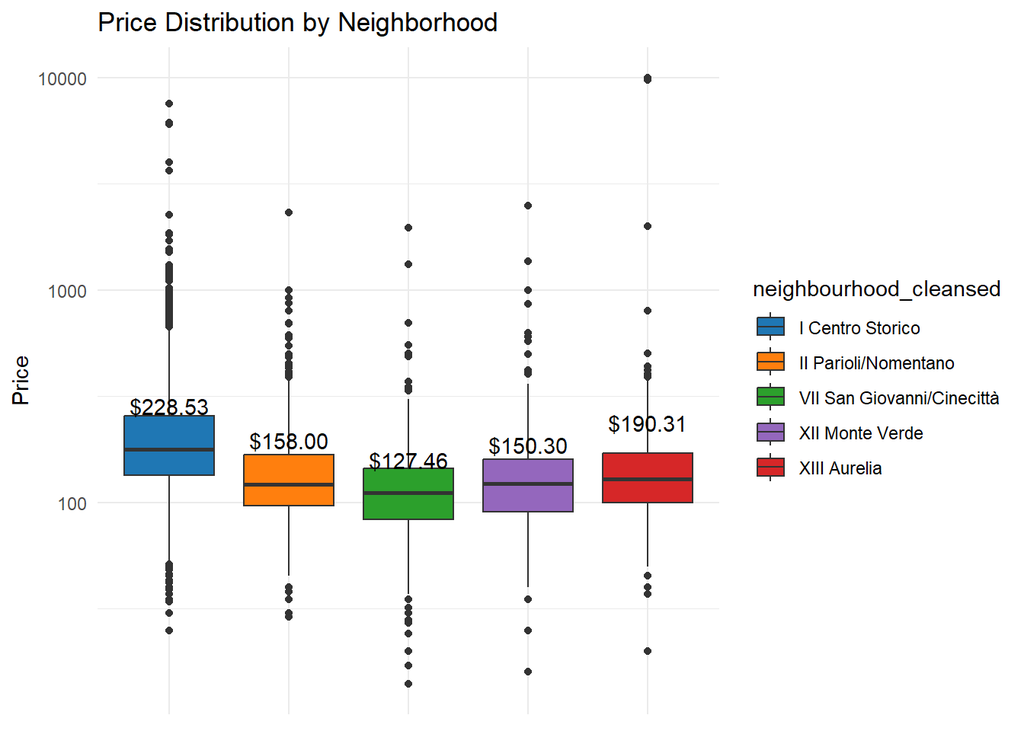

We will now analyze the types of properties listed on the site. A preliminary analysis of the dataset indicates that the predominant category is ‘Entire rental unit,’ which represents approximately 50% of the dataset.

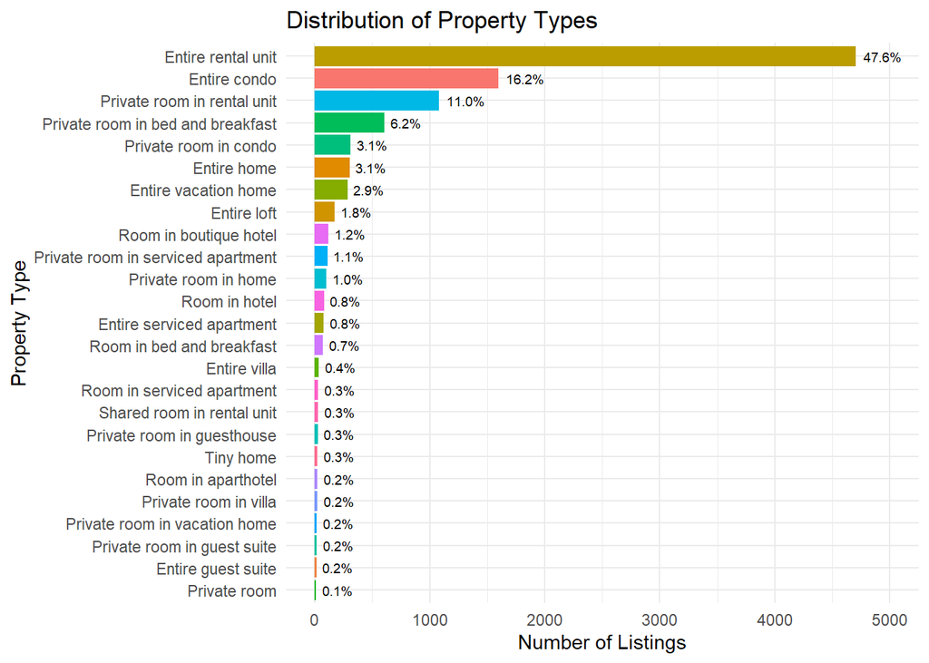

We can again observe that the average price varies quite significantly depending on the type of accommodation chosen. Specifically, the average price for an *‘Entire rental unit’* is approximately twice as high as that for a *‘Private room’* within the same unit.

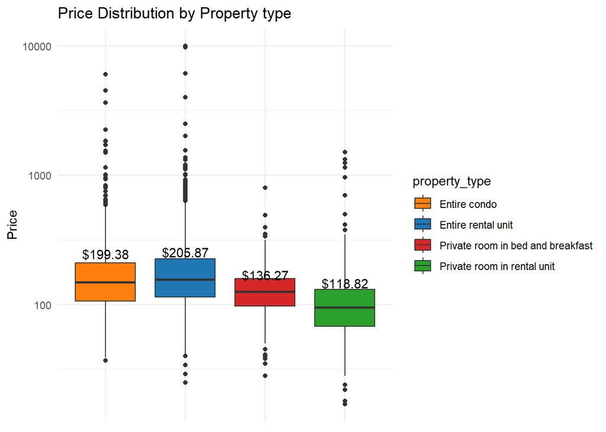

Talking about room types, we can clearly see a predominance of the ‘Entire home/apt’ rather than ‘Private room’. after all, the airbnb platform is made specifically for these room types and not for hotels (like its competitor Booking).

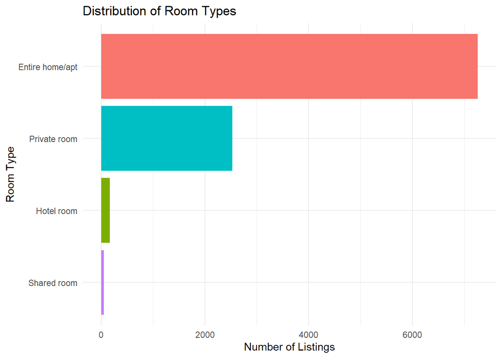

Also here is trivial that the prices of Entire home and Hotel Room are almost the same, with the Entire home prices slightly higher. The price drop for Private rooms and in specific is really low in Shared rooms, but that’s fine because you don’t have the entire unit for yourself but you must share it in some way (e.g. hostels).

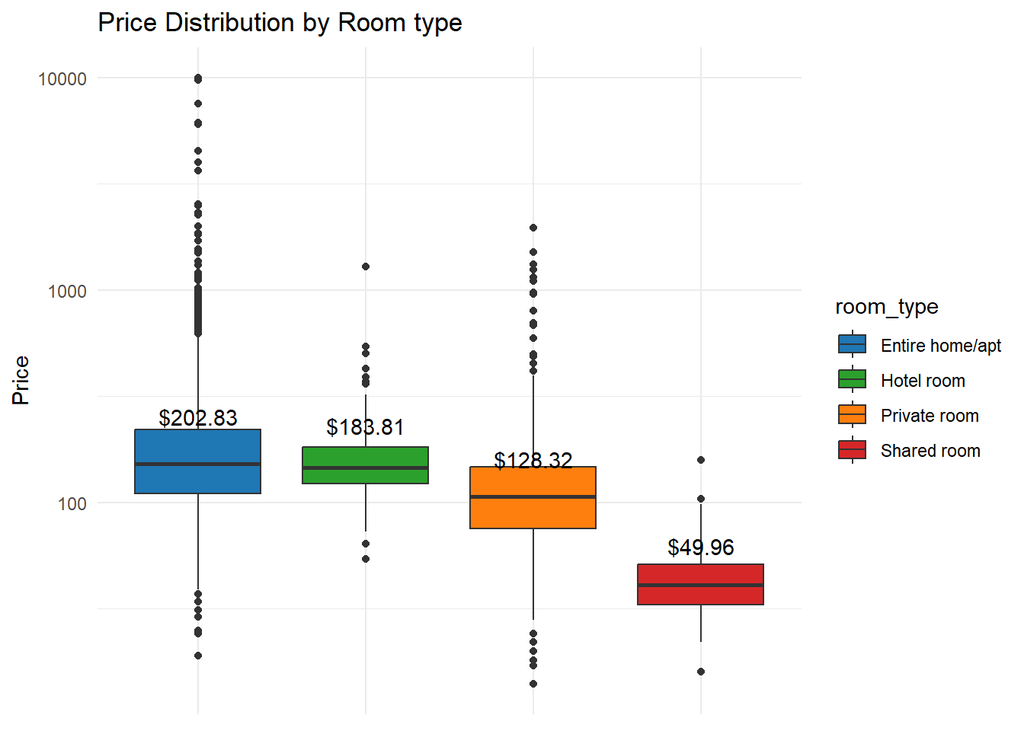

To go further in the analysis, we can observe that there is a strong dominance of accommodation that can host groups from 3 to 6 people (maybe families or a group of friends), followed by smaller ones with max 1-2 guests. The same situation can be observed looking at the distribution of ‘beds’, with a strong dominance of places with 2 beds (that could host up to 4 people)

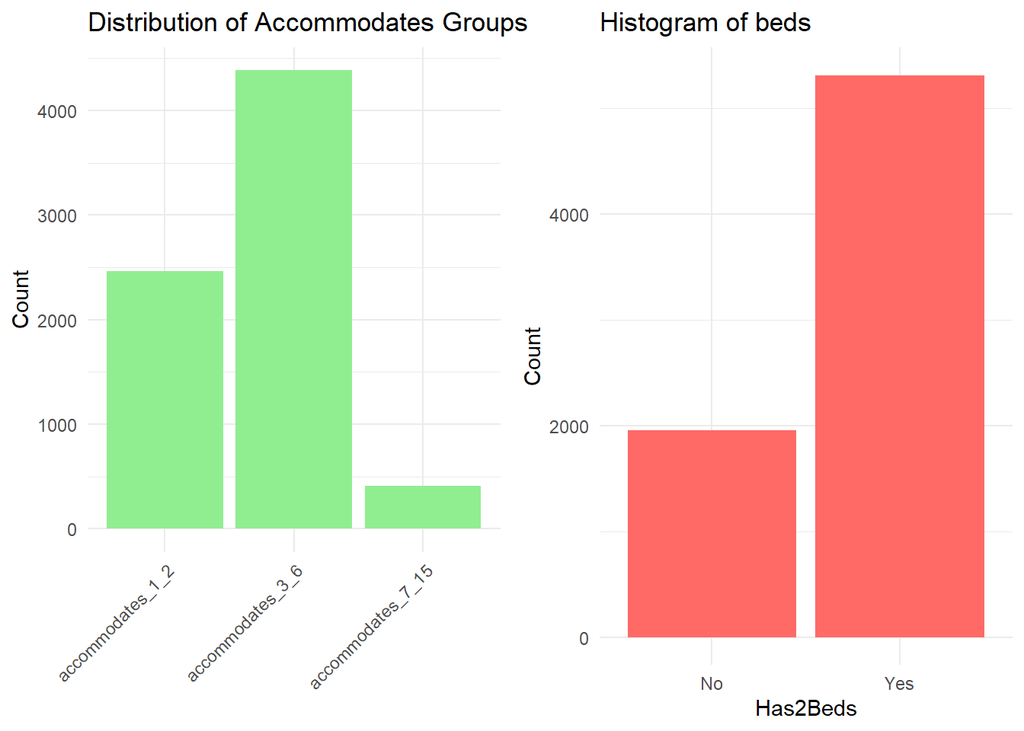

Here we can see the distribution of the numerical features of interest.

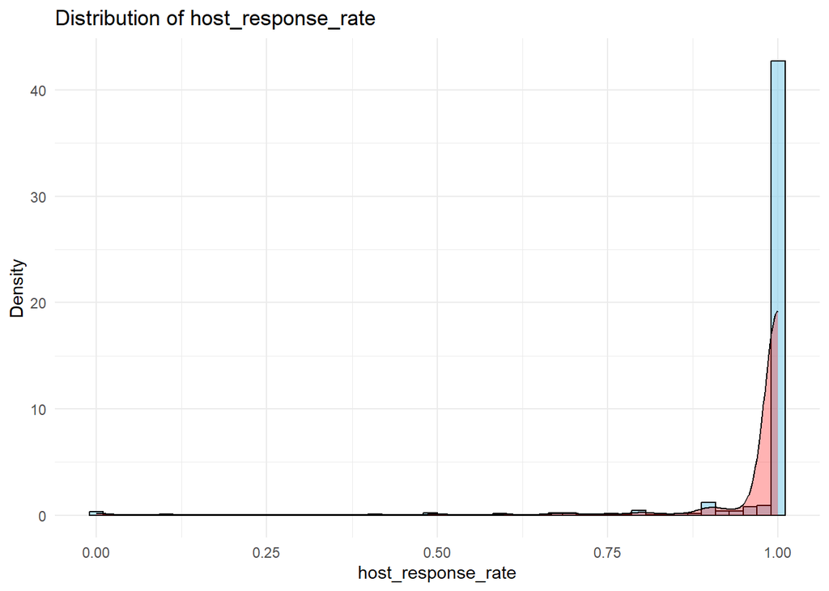

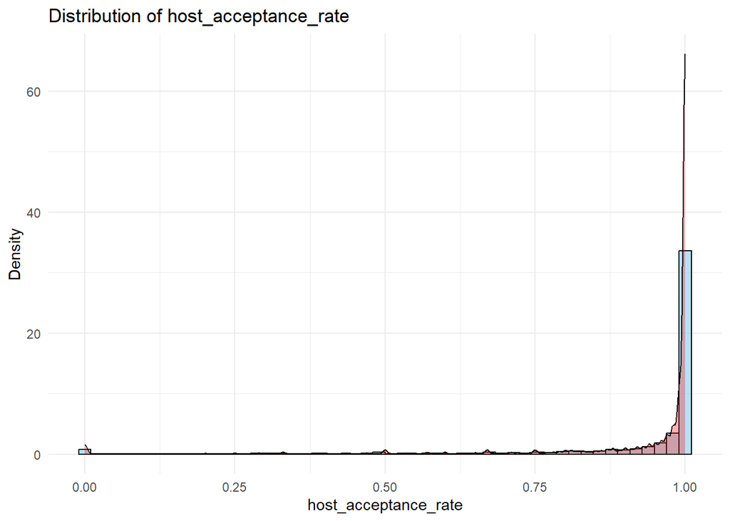

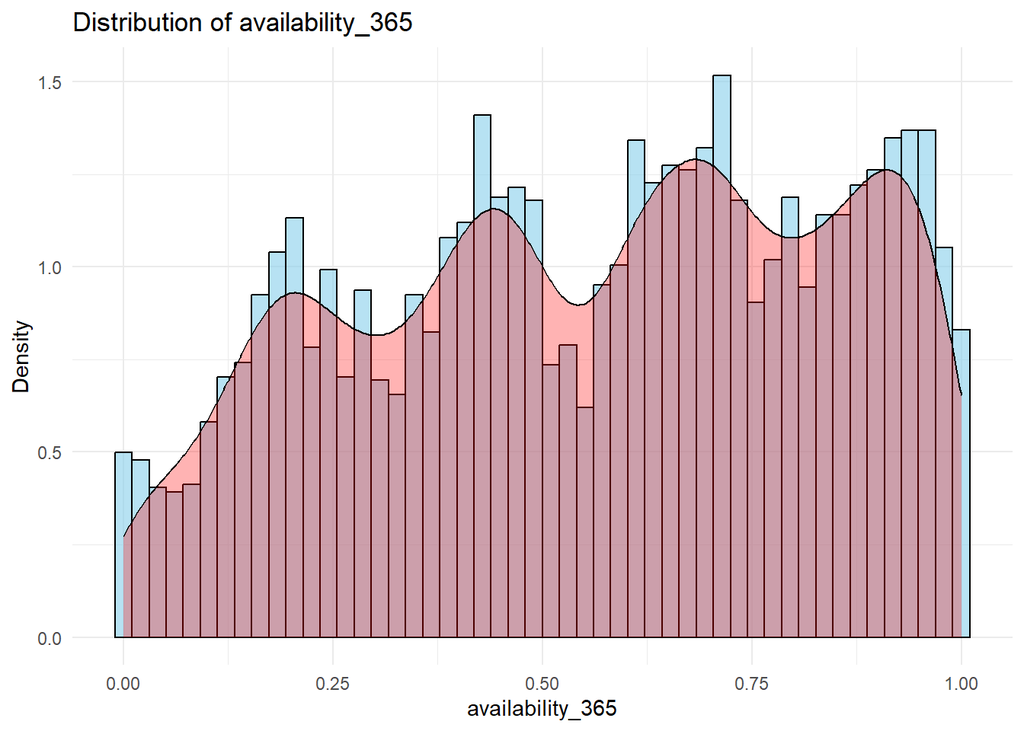

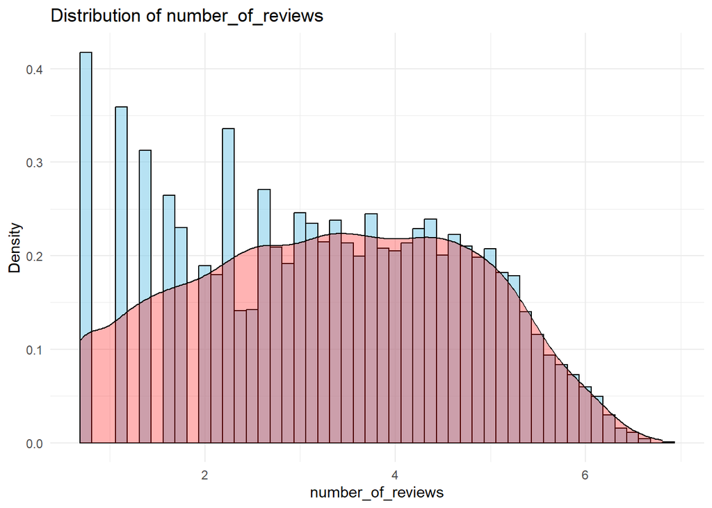

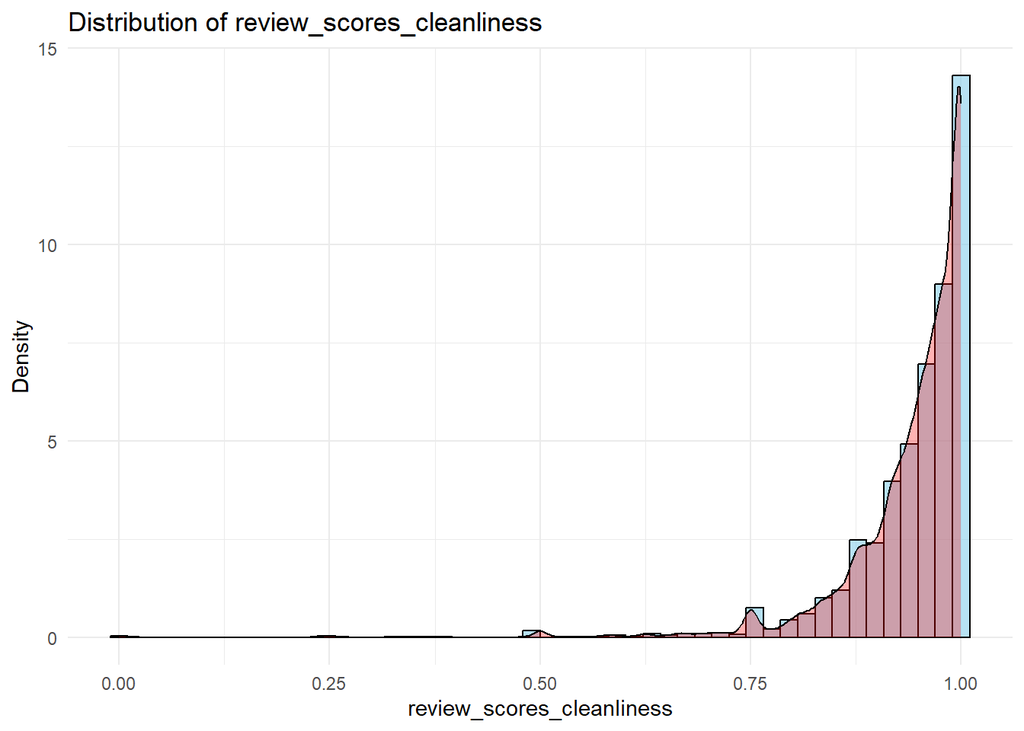

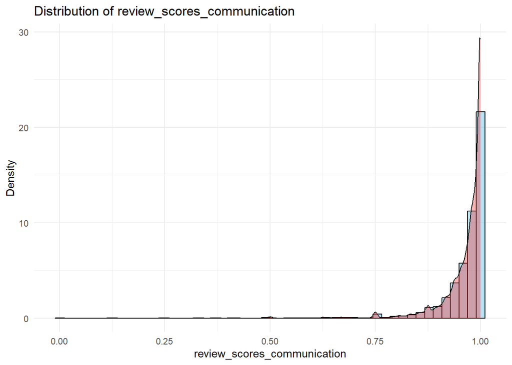

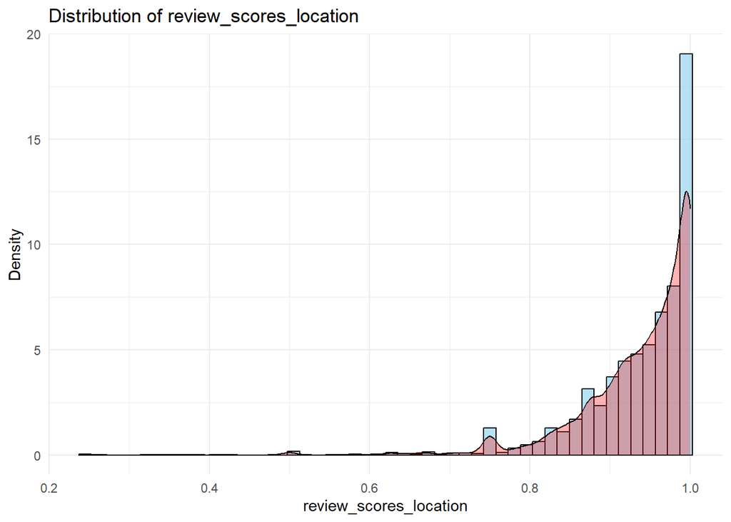

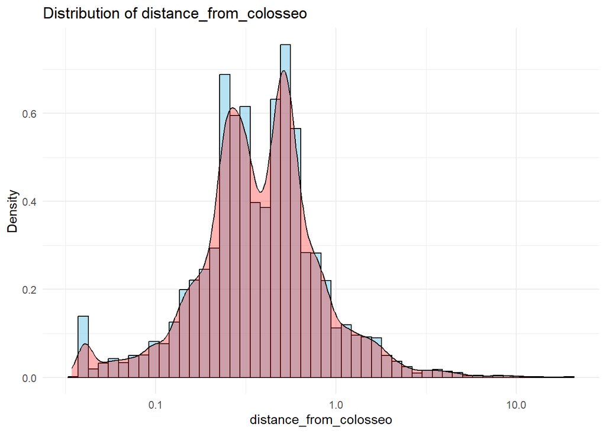

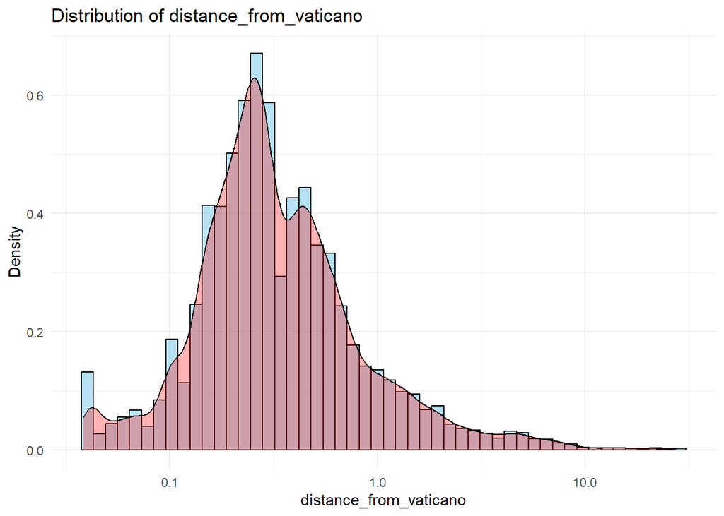

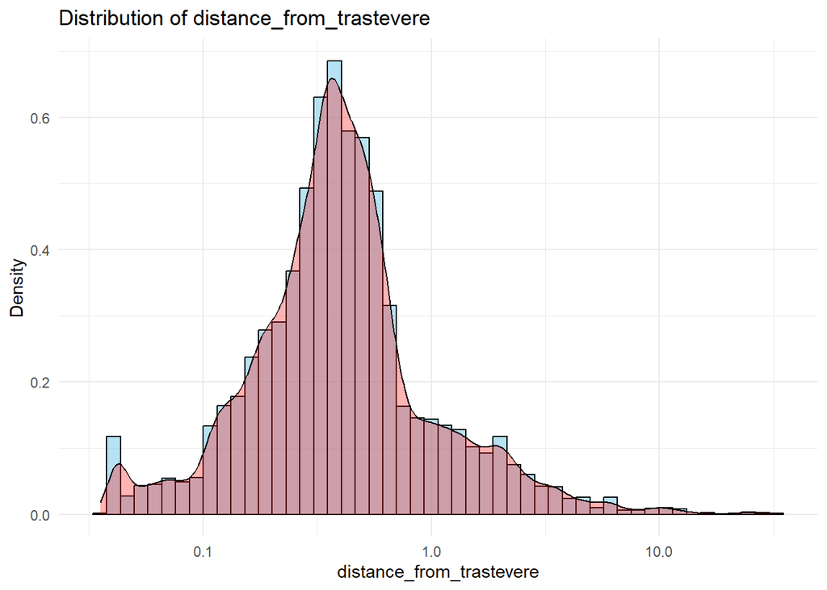

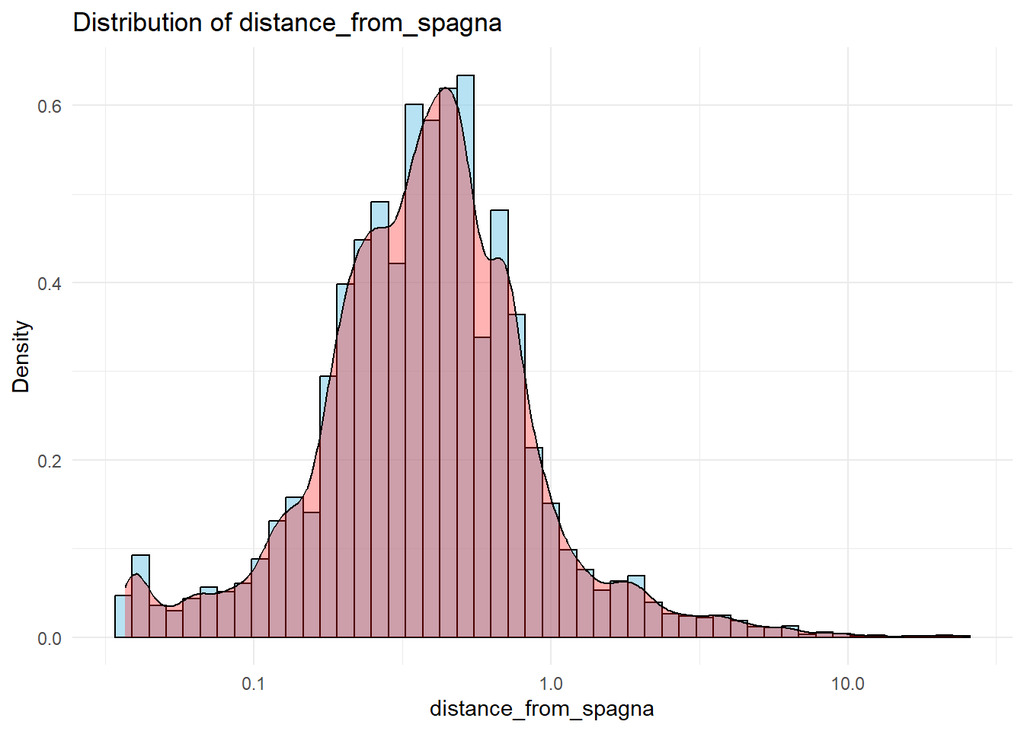

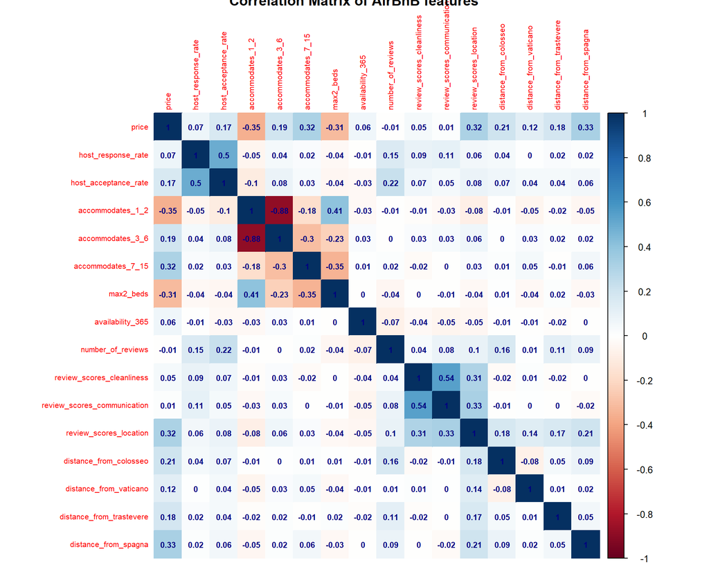

Based on our analysis, the columns most strongly correlated with price are:

- accommodates_*
- beds
- host acceptance rate
- review score location
- distances from points of interest

To mitigate redundancy and multicollinearity, we will retain only the *review_score_location* variable. This variable exhibits a significant correlation with price and demonstrates a high correlation with other review scores. The *host_response_rate* will be excluded due to its low informational value, along with the *number_of_reviews* and availability throughout the year.

# Models

## First Model

```
model {
  for (i in 1:N) {
    price[i] ~ dnorm(mu[i], tau)
    mu[i] <- beta0 + beta1 * host_acceptance_rate[i] + beta2 * accommodates_1_2[i] +
             beta3 * accommodates_3_6[i] + beta4 * accommodates_7_15[i] +
             beta5 * max2_beds[i] + beta6 * review_scores_location[i] +
             beta7 * distance_from_colosseo[i] + beta8 * distance_from_vaticano[i] +
             beta9 * distance_from_trastevere[i] + beta10 * distance_from_spagna[i]
  }

  tau <- 1 / (sigma * sigma)
  sigma ~ dunif(0, 100)

  beta0 ~ dnorm(0, 0.01)
  beta1 ~ dnorm(0, 0.01)
  beta2 ~ dnorm(0, 0.01)
  beta3 ~ dnorm(0, 0.01)
  beta4 ~ dnorm(0, 0.01)
  beta5 ~ dnorm(0, 0.01)
  beta6 ~ dnorm(0, 0.01)
  beta7 ~ dnorm(0, 0.01)
  beta8 ~ dnorm(0, 0.01)
  beta9 ~ dnorm(0, 0.01)
  beta10 ~ dnorm(0, 0.01)
}
```

```r
set.seed(123)
model_1 <- jags(data = data_jags,
                parameters.to.save=params,
                model.file= "standard_bayesian_linear_model_2.txt",
                n.chains = 3,
                n.iter=5000,
                n.burnin=1000,
                n.thin=5
                )
```

```
## module glm loaded
```

```r
model_1
```

```
## Inference for Bugs model at "standard_bayesian_linear_model_2.txt", fit using jags,
##  3 chains, each with 5000 iterations (first 1000 discarded), n.thin = 5
##  n.sims = 2400 iterations saved
##           mu.vect sd.vect     2.5%      25%      50%      75%    97.5%  Rhat
## beta0       5.285   0.341    4.599    5.068    5.281    5.511    5.952 1.003
## beta1       0.273   0.030    0.215    0.252    0.272    0.294    0.333 1.001
## beta10      0.162   0.006    0.149    0.157    0.162    0.166    0.174 1.001
## beta2      -2.226   0.328   -2.867   -2.439   -2.219   -2.014   -1.580 1.004
## beta3      -1.946   0.328   -2.584   -2.166   -1.939   -1.735   -1.297 1.004
## beta4      -1.407   0.330   -2.034   -1.629   -1.399   -1.196   -0.752 1.004
## beta5      -0.183   0.014   -0.209   -0.192   -0.183   -0.173   -0.155 1.001
## beta6       1.478   0.081    1.309    1.426    1.479    1.534    1.635 1.001
## beta7       0.134   0.008    0.118    0.128    0.133    0.139    0.150 1.001
## beta8       0.036   0.005    0.027    0.033    0.036    0.040    0.045 1.001
## beta9       0.059   0.004    0.051    0.056    0.059    0.062    0.068 1.001
## sigma       0.463   0.004    0.455    0.460    0.463    0.465    0.470 1.003
## deviance 9417.350   4.999 9409.758 9413.776 9416.654 9420.249 9429.109 1.001
##          n.eff
## beta0      690
## beta1     2200
## beta10    2400
## beta2      620
## beta3      630
## beta4      620
## beta5     2400
## beta6     2400
## beta7     2400
## beta8     2400
## beta9     2400
## sigma      940
## deviance  2000
##
## For each parameter, n.eff is a crude measure of effective sample size,
## and Rhat is the potential scale reduction factor (at convergence, Rhat=1).
##
## DIC info (using the rule, pD = var(deviance)/2)
## pD = 12.5 and DIC = 9429.8
## DIC is an estimate of expected predictive error (lower deviance is better).
```

Parameters:

- *beta0* (Intercept) has a mean of 5.285 with a 95% credible interval [4.599, 5.952], indicating a positive intercept.
- *beta1* through *beta9* represent various coefficients with estimated values ranging from small positive effects to significant negative effects.
- *sigma* (residual standard deviation) is estimated at 0.463 with a 95% credible interval [0.455, 0.470], suggesting low variability in residuals.
- The model’s *Rhat* values are close to 1, indicating good convergence, and effective sample sizes are generally high, ensuring reliable parameter estimates.
- The deviance value of 9417.350 suggests the overall fit of the model, with a narrow credible interval indicating stability in fit across iterations.

Now let’s provide some diagnostic in order to see if results are reliable.

### Density and TracePlot

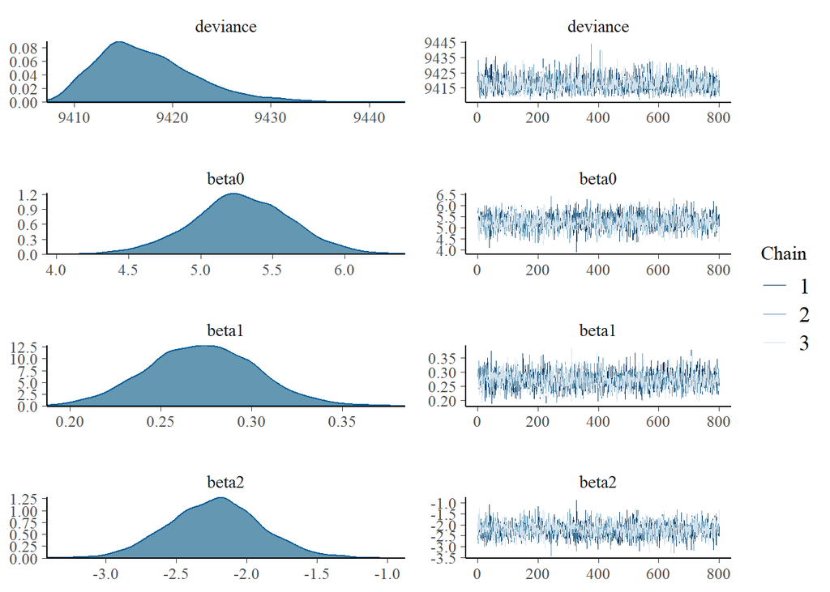

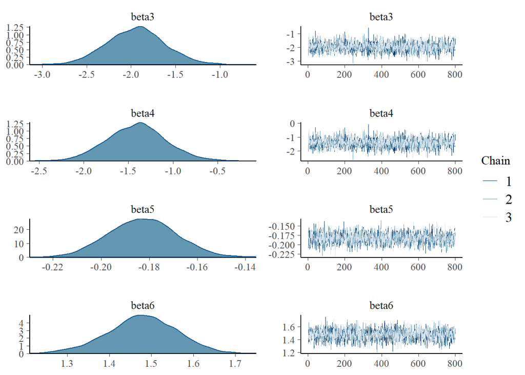

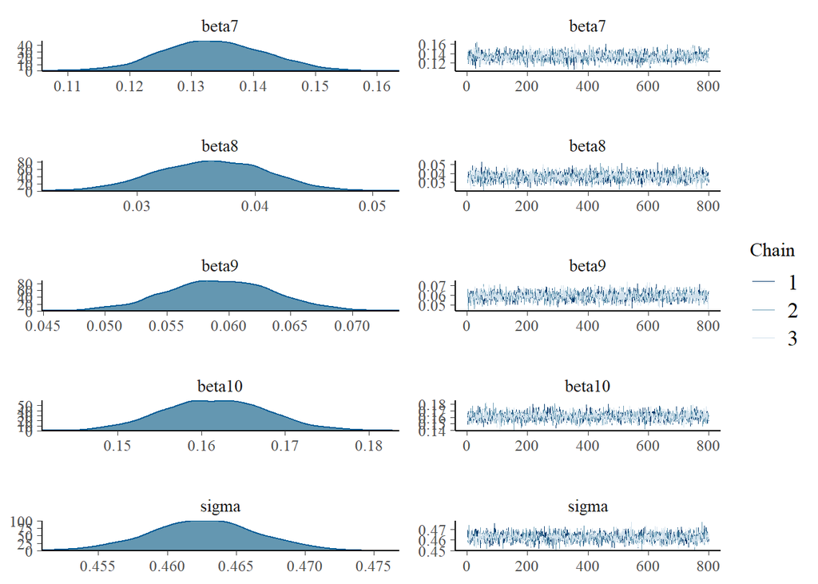

### Autocorrelation

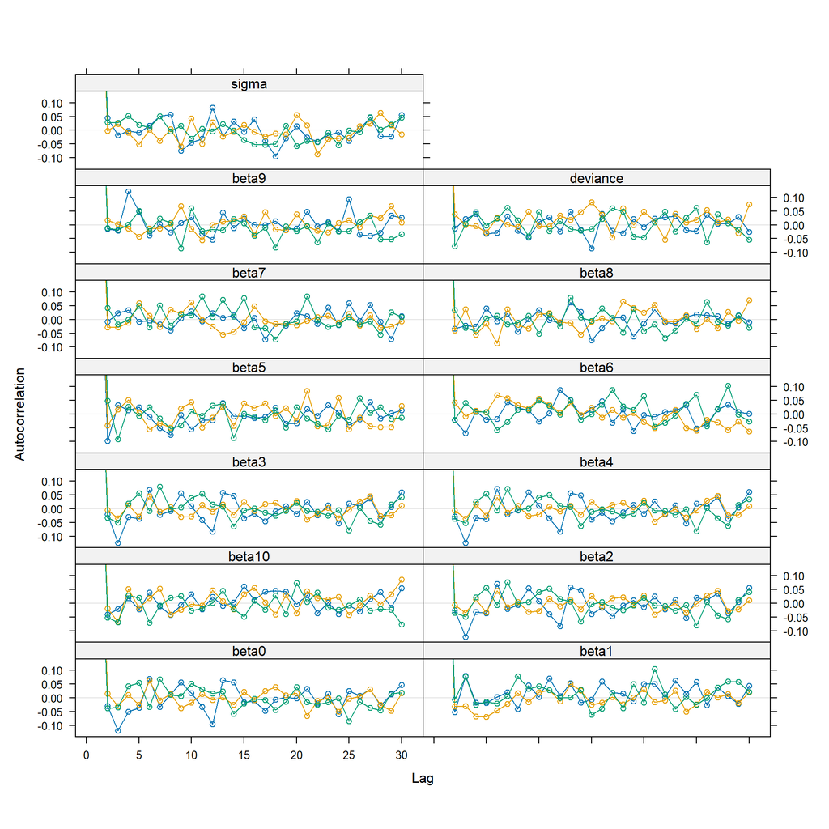

```
##               beta0       beta1       beta10       beta2        beta3
## Lag 0    1.00000000  1.00000000  1.000000000  1.00000000  1.000000000
## Lag 5   -0.01732485 -0.02988043 -0.037062995 -0.02229153 -0.019952110
## Lag 25   0.03266867 -0.02107409 -0.004173506  0.03628135  0.035400759
## Lag 50   0.00445719  0.04259103 -0.016102148  0.01025922  0.009271245
## Lag 250 -0.01627108 -0.01254510 -0.003847600 -0.01201120 -0.011790706
##                beta4       beta5         beta6        beta7        beta8
## Lag 0    1.000000000  1.00000000  1.0000000000  1.000000000  1.000000000
## Lag 5   -0.023809653 -0.03038553 -0.0002748602  0.001968573 -0.013624641
## Lag 25   0.034955174 -0.01344859 -0.0031418606 -0.006085132 -0.027197427
## Lag 50   0.007634192 -0.02636250  0.0224650447  0.024920948  0.013243493
## Lag 250 -0.009294214  0.01513228  0.0464140897  0.010030392  0.006552313
##                beta9      deviance       sigma
## Lag 0    1.000000000  1.0000000000  1.00000000
## Lag 5   -0.003382687 -0.0176825586  0.02351570
## Lag 25  -0.025069209  0.0064836647  0.00950287
## Lag 50  -0.036199539 -0.0004371489 -0.02470081
## Lag 250  0.010765570 -0.0195324987 -0.02039158
```

The autocorrelation diagnostics indicate good mixing of the MCMC chains, with autocorrelation values going to 0 as the lags increase, suggesting that the samples are effectively independent and well-behaved.

### Stationarity

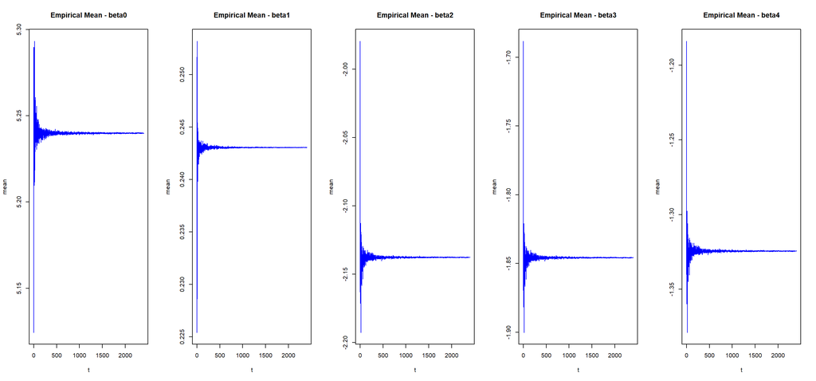

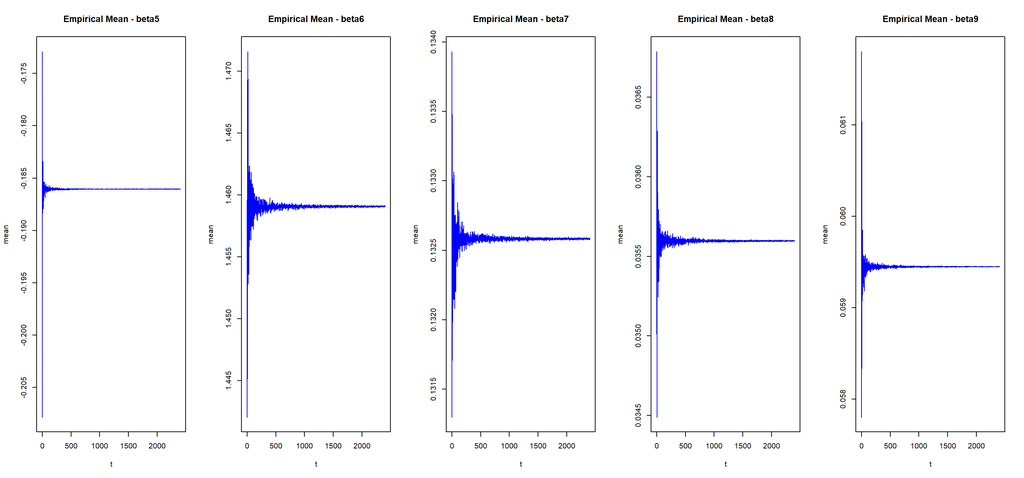

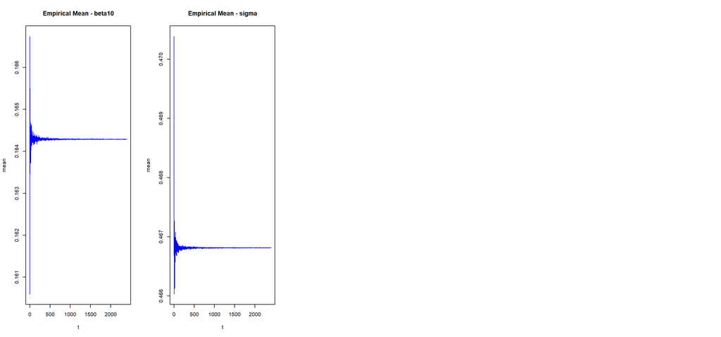

The plots of empirical means for each parameter clearly show that the means stabilize over time, indicating that the MCMC chains have converged and the parameter estimates are reliable.

### Geweke diagnostic

The Geweke diagnostic computes the ratio of the estimated means between the first 10% of iterations and the last 50%, normalized by standard errors. In order to be good, all Z-scores must be within $|Z| < 1.96$.

```r
coda::geweke.diag(coda.fit)
```

```
## [[1]]
##
## Fraction in 1st window = 0.1
## Fraction in 2nd window = 0.5
##
##    beta0    beta1   beta10    beta2    beta3    beta4    beta5    beta6
##   0.9094   0.4210  -3.2207  -0.7951  -0.7953  -0.9048  -0.4408   0.0760
##    beta7    beta8    beta9 deviance    sigma
##  -0.4405  -0.7814  -0.6085   1.5267   1.1675
##
##
## [[2]]
##
## Fraction in 1st window = 0.1
## Fraction in 2nd window = 0.5
##
##    beta0    beta1   beta10    beta2    beta3    beta4    beta5    beta6
## -0.78863  2.28999  1.65348  0.48911  0.51322  0.51793  1.31061  0.56888
##    beta7    beta8    beta9 deviance    sigma
##  0.79540 -1.22926  0.03373  2.01678  1.07237
##
##
## [[3]]
##
## Fraction in 1st window = 0.1
## Fraction in 2nd window = 0.5
##
##    beta0    beta1   beta10    beta2    beta3    beta4    beta5    beta6
##  -1.2657   1.1245   0.1341   1.2432   1.2698   1.2333   0.5433  -0.2732
##    beta7    beta8    beta9 deviance    sigma
##  -0.5140   0.7961   0.3792  -1.6167  -0.3592
```

### Heidelberger diagnostic

The Heidelberger and Welch diagnostic assesses MCMC convergence by evaluating the stationarity of parameter estimates and the precision of confidence intervals. A “passed” result for the stationarity test indicates that the chains have stabilized, while passing the halfwidth test suggests that the parameter estimates are precise and reliable. With all parameters meeting these criteria, the test supports the conclusion that the MCMC chains have converged well, ensuring robust and dependable results.

The Heidel test first divide the MCMC chain into several segments, each one long enough to provide a reasonable estimate of the parameters. Suddenly, for each segment, the test checks if the sample means and variances are stationary. If they are, it suggests that the chain has converged.

```r
coda.fit <- coda::as.mcmc(model_1)
coda::heidel.diag(coda.fit)
```

```
## [[1]]
##
##          Stationarity start     p-value
##          test         iteration
## beta0    passed       1         0.9131
## beta1    passed       1         0.0506
## beta10   passed       1         0.1264
## beta2    passed       1         0.8521
## beta3    passed       1         0.8652
## beta4    passed       1         0.8300
## beta5    passed       1         0.9615
## beta6    passed       1         0.1172
## beta7    passed       1         0.5063
## beta8    passed       1         0.0638
## beta9    passed       1         0.7276
## deviance passed       1         0.4011
## sigma    passed       1         0.6316
##
##          Halfwidth Mean      Halfwidth
##          test
## beta0    passed       5.2996 0.018991
## beta1    passed       0.2742 0.002193
## beta10   passed       0.1616 0.000428
## beta2    passed      -2.2388 0.018918
## beta3    passed      -1.9588 0.018988
## beta4    passed      -1.4203 0.018778
## beta5    passed      -0.1825 0.000870
## beta6    passed       1.4750 0.005213
## beta7    passed       0.1333 0.000563
## beta8    passed       0.0364 0.000326
## beta9    passed       0.0591 0.000336
## deviance passed    9417.3137 0.338495
## sigma    passed       0.4629 0.000277
##
## [[2]]
##
##          Stationarity start     p-value
##          test         iteration
## beta0    passed         1       0.2349
## beta1    passed        81       0.1941
```

[output cut: 46 more lines]

```
##          Halfwidth Mean      Halfwidth
##          test
## beta0    passed       5.2588 0.023415
## beta1    passed       0.2719 0.002171
## beta10   passed       0.1618 0.000378
## beta2    passed      -2.1993 0.022444
## beta3    passed      -1.9199 0.022445
## beta4    passed      -1.3810 0.022592
## beta5    passed      -0.1826 0.000915
## beta6    passed       1.4787 0.005683
## beta7    passed       0.1339 0.000568
## beta8    passed       0.0362 0.000320
## beta9    passed       0.0593 0.000307
## deviance passed    9417.1757 0.319495
## sigma    passed       0.4624 0.000262
```

### Gelman Rubin diagnostic

```r
coda::gelman.diag(coda.fit)
```

```
## Potential scale reduction factors:
##
##          Point est. Upper C.I.
## beta0             1       1.01
## beta1             1       1.01
## beta10            1       1.00
## beta2             1       1.01
## beta3             1       1.01
## beta4             1       1.01
## beta5             1       1.00
## beta6             1       1.00
## beta7             1       1.01
## beta8             1       1.02
## beta9             1       1.00
## deviance          1       1.00
## sigma             1       1.01
##
## Multivariate psrf
##
## 1.01
```

It compares the variance within each chain to the variance between chains. The diagnostic provides a point estimate and an upper confidence interval (C.I.).

We can say that all the parameters converge for this diagnostic (Upper CI are all $\simeq 1$)

### HPD

```r
chainMat <- model_1$BUGSoutput$sims.matrix

(p.HPD.jags <- coda::HPDinterval(as.mcmc(chainMat)))
```

```
##                  lower         upper
## beta0       4.59142322    5.93925331
## beta1       0.21449624    0.33207668
## beta10      0.14825876    0.17269148
## beta2      -2.88284465   -1.60040158
## beta3      -2.59990495   -1.32674744
## beta4      -2.03554936   -0.75238225
## beta5      -0.21005507   -0.15628360
## beta6       1.32060665    1.64324222
## beta7       0.11780681    0.15012417
## beta8       0.02675720    0.04454048
## beta9       0.05076915    0.06776726
## deviance 9409.07958683 9427.47731745
## sigma       0.45541446    0.47073926
## attr(,"Probability")
## [1] 0.95
```

The HPD intervals provide a credible range for each parameter, with significant parameters having intervals that do not include zero.

We can see from the HPD that no interval include zero, suggesting that all the parameters are significative.

### Approximation error

|  | MCSE |
| --- | --- |
| beta0 | 0.007602261885407064 |
| beta1 | 0.0006397686529575718 |
| beta10 | 0.0001351152399694488 |
| beta2 | 0.007257352620537073 |
| beta3 | 0.007256723150678435 |
| beta4 | 0.007233565861144059 |
| beta5 | 0.0002989575571639242 |
| beta6 | 0.001799497791615374 |
| beta7 | 0.0001805834430304745 |
| beta8 | 9.764804855184474e-05 |

[output cut: 3 more lines]

The approximation error is calculated dividing the standard deviation of the samples by the square root of the effective sample size. The smaller the MCSE(Monte Carlo standard Error), the more precise the estimate of the parameter.

### Posterior uncertainty

|  | V1 |
| --- | --- |
| beta0 | 0.1159731019952188 |
| beta1 | 0.0009004147294193397 |
| beta2 | 0.1077819731533836 |
| beta3 | 0.1075261985920204 |
| beta4 | 0.1085842905245 |
| beta5 | 0.0001953721617747255 |
| beta6 | 0.006628850364460854 |
| beta7 | 6.974054987889805e-05 |
| beta8 | 2.144931892399364e-05 |
| beta9 | 1.852318458759106e-05 |

[output cut: 2 more lines]

The posterior uncertainties for beta1, beta5, beta6, beta7, beta8, beta9 and beta10 are very low, indicating high confidence in these estimates.

beta0, beta2, beta3 and beta4 have higher uncertainties, suggesting more variability and less precise information from the data.

The uncertainty for sigma is low and that indicates a precise estimate of the variability in the data.

### RMSE Model 1

```
## The RMSE for the Bayesian Regression is: 0.4621712
```

## Second Model

```
model {
  for (i in 1:N) {
    price[i] ~ dnorm(mu[i], tau)
    mu[i] <- beta0 + beta1 * host_acceptance_rate[i] + beta2 * accommodates_1_2[i] +
             beta3 * accommodates_3_6[i] + beta4 * accommodates_7_15[i] +
             beta5 * max2_beds[i] + beta6 * review_scores_location[i] +
             beta7 * distance_from_colosseo[i] + beta8 * distance_from_vaticano[i] +
             beta9 * distance_from_trastevere[i] + beta10 * distance_from_spagna[i]
  }

  tau <- 1 / (sigma * sigma)
  sigma ~ dunif(0, 100)

  beta0 ~ dnorm(1, tau_beta)
  beta1 ~ dnorm(0, tau_beta)
  beta2 ~ dnorm(0, tau_beta)
  beta3 ~ dnorm(0, tau_beta)
  beta4 ~ dnorm(0, tau_beta)
  beta5 ~ dnorm(0, tau_beta)
  beta6 ~ dnorm(0, tau_beta)
  beta7 ~ dnorm(0.5, tau_beta)
  beta8 ~ dnorm(0, tau_beta)
  beta9 ~ dnorm(0, tau_beta)
  beta10 ~ dnorm(0.5, tau_beta)

  tau_beta ~ dgamma(0.1, 0.1)
}
```

```r
model_2 <- jags(data = data_jags,
                parameters.to.save=params,
                model.file= "regularization_model.txt",
                n.chains = 3,
                n.iter=5000,
                n.burnin=1000,
                n.thin=5
                )
model_2
```

```
## Inference for Bugs model at "regularization_model.txt", fit using jags,
##  3 chains, each with 5000 iterations (first 1000 discarded), n.thin = 5
##  n.sims = 2400 iterations saved
##           mu.vect sd.vect     2.5%      25%      50%      75%    97.5%  Rhat
## beta0       4.898   0.355    4.235    4.649    4.898    5.137    5.605 1.001
## beta1       0.273   0.030    0.215    0.253    0.273    0.292    0.332 1.005
## beta10      0.162   0.006    0.149    0.158    0.162    0.166    0.174 1.003
## beta2      -1.843   0.345   -2.510   -2.080   -1.848   -1.600   -1.166 1.001
## beta3      -1.563   0.345   -2.230   -1.799   -1.571   -1.318   -0.890 1.001
## beta4      -1.023   0.346   -1.695   -1.258   -1.028   -0.782   -0.344 1.001
## beta5      -0.182   0.014   -0.209   -0.191   -0.182   -0.173   -0.155 1.001
## beta6       1.481   0.082    1.317    1.425    1.482    1.536    1.641 1.004
## beta7       0.134   0.008    0.117    0.128    0.134    0.139    0.150 1.001
## beta8       0.036   0.005    0.027    0.033    0.036    0.040    0.045 1.003
## beta9       0.059   0.004    0.051    0.056    0.059    0.062    0.067 1.001
## sigma       0.463   0.004    0.455    0.460    0.463    0.465    0.470 1.000
## deviance 9418.806   5.630 9409.969 9414.722 9418.075 9422.122 9431.472 1.002
##          n.eff
## beta0     2400
## beta1      420
## beta10     940
## beta2     2400
## beta3     2400
## beta4     2400
## beta5     2400
## beta6      770
## beta7     2400
## beta8      810
## beta9     2400
## sigma     2400
## deviance  1100
##
## For each parameter, n.eff is a crude measure of effective sample size,
## and Rhat is the potential scale reduction factor (at convergence, Rhat=1).
##
## DIC info (using the rule, pD = var(deviance)/2)
## pD = 15.8 and DIC = 9434.6
## DIC is an estimate of expected predictive error (lower deviance is better).
```

### Density and TracePlot

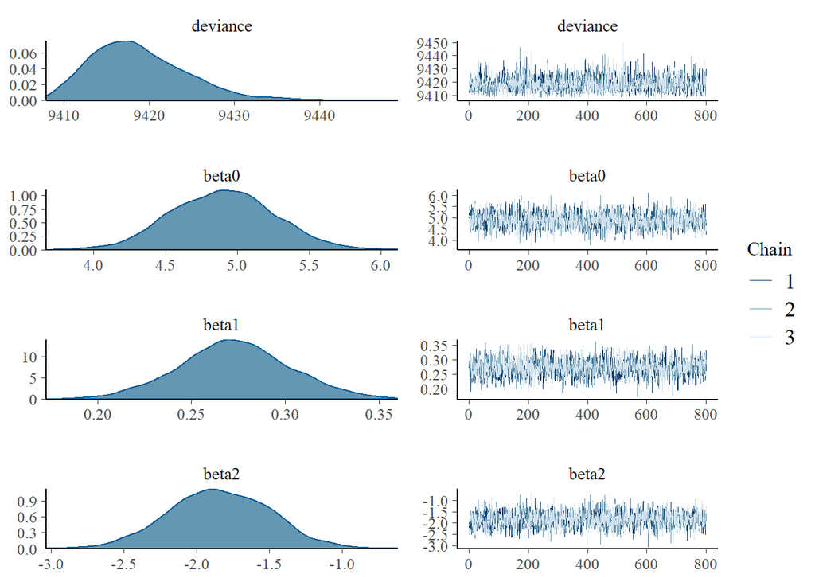

```r
chainArray <- model_2$BUGSoutput$sims.array

bayesplot::mcmc_combo(chainArray, pars = c("deviance", "beta0", "beta1", "beta2"))
```

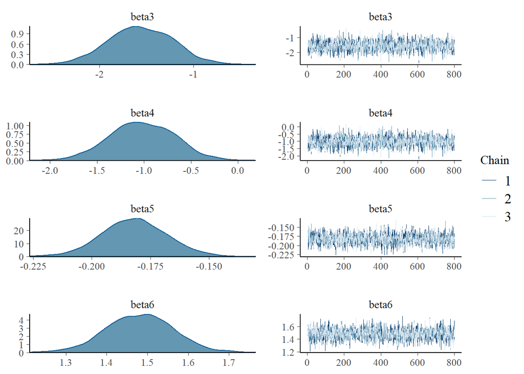

```r
bayesplot::mcmc_combo(chainArray, pars = c("beta3", "beta4", "beta5", "beta6"))
```

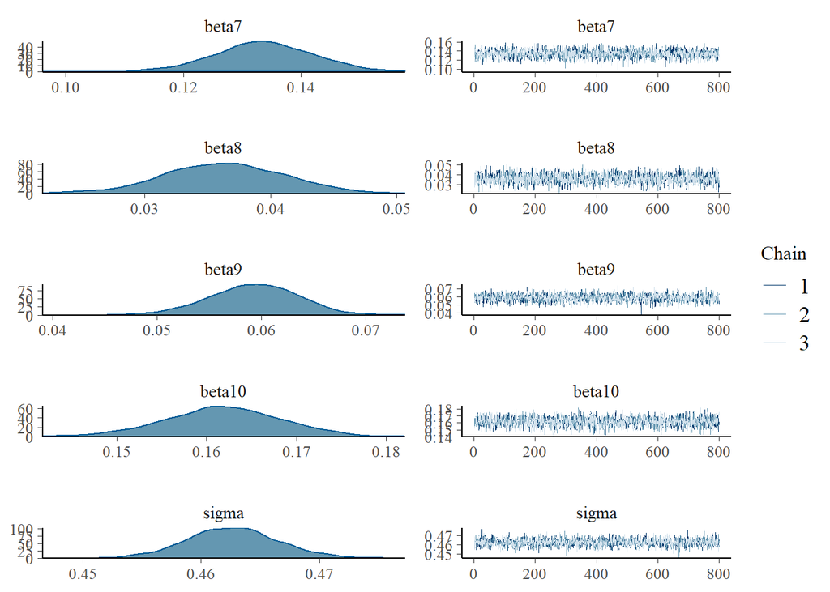

```r
bayesplot::mcmc_combo(chainArray, pars = c("beta7", "beta8", "beta9", "beta10", "sigma"))
```

### Autocorrelation

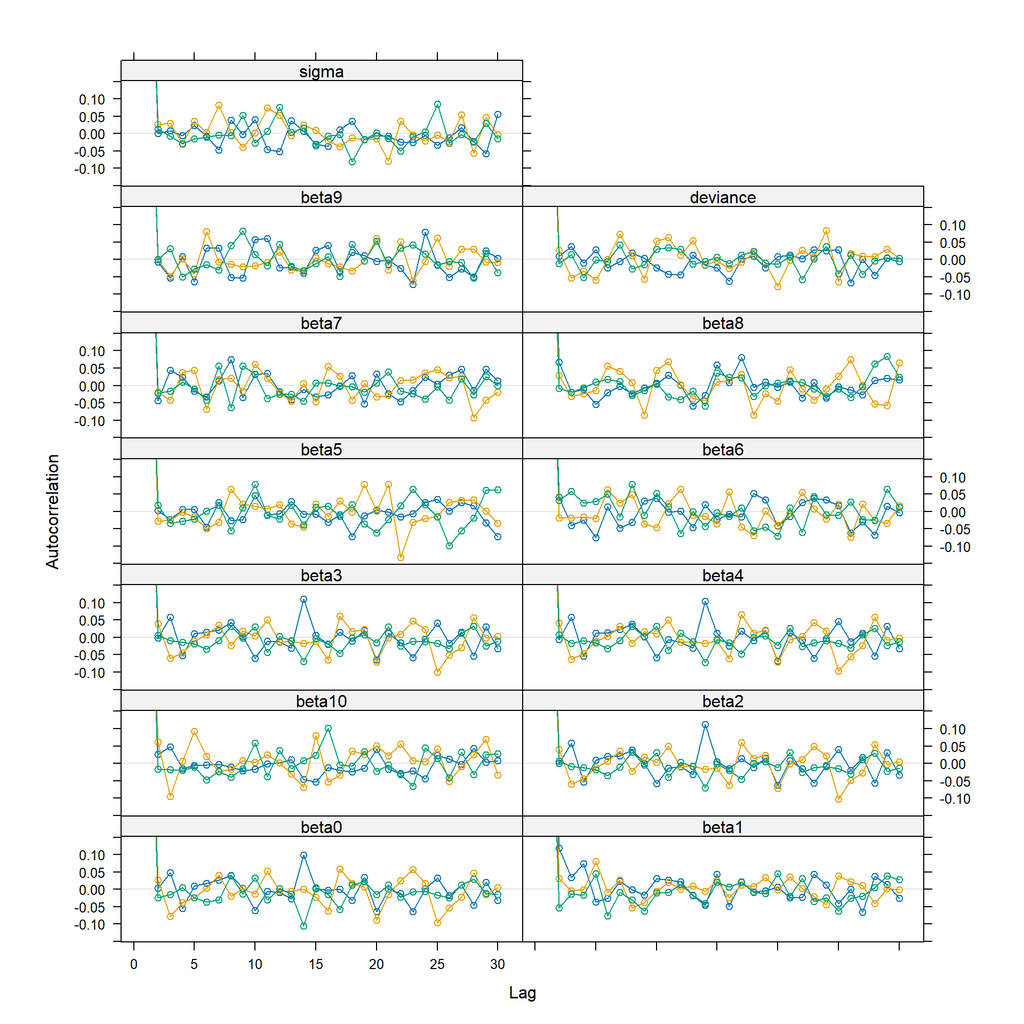

```
##                beta0        beta1       beta10        beta2        beta3
## Lag 0    1.000000000  1.000000000  1.000000000  1.000000000  1.000000000
## Lag 5    0.002298626  0.032349197  0.023475681  0.015485365  0.014584462
## Lag 25  -0.005694392 -0.037164651 -0.010445213 -0.002922841 -0.003767294
## Lag 50   0.005080105  0.012867465 -0.005283971 -0.001281181 -0.001240581
## Lag 250 -0.023419635  0.006046855 -0.028451944 -0.018030667 -0.017678595
##                beta4        beta5       beta6        beta7       beta8
## Lag 0    1.000000000  1.000000000  1.00000000  1.000000000  1.00000000
## Lag 5    0.014274265 -0.003009982  0.01782317 -0.028284530  0.02885206
## Lag 25  -0.005451126 -0.031292180  0.04228108 -0.048016584  0.01727260
## Lag 50   0.002382600 -0.004335345  0.01179728  0.005918400  0.02159790
## Lag 250 -0.018453437  0.020372679 -0.00541100 -0.004209874 -0.01113774
##                beta9     deviance        sigma
## Lag 0    1.000000000  1.000000000  1.000000000
## Lag 5   -0.002799408  0.008306332  0.013088369
## Lag 25   0.032993472 -0.009528612 -0.005198408
## Lag 50   0.011120449  0.018946917  0.011255782
## Lag 250 -0.013767690  0.009575711 -0.016627753
```

Also in this model the shape of the convergence looks like similar with the chains that mix well.

### Heidel test

```
## [[1]]
##
##          Stationarity start     p-value
##          test         iteration
## beta0    passed       1         0.951
## beta1    passed       1         0.804
## beta10   passed       1         0.684
## beta2    passed       1         0.890
## beta3    passed       1         0.877
## beta4    passed       1         0.932
## beta5    passed       1         0.730
## beta6    passed       1         0.737
## beta7    passed       1         0.455
## beta8    passed       1         0.473
## beta9    passed       1         0.162
## deviance passed       1         0.768
## sigma    passed       1         0.920
##
##          Halfwidth Mean      Halfwidth
##          test
## beta0    passed       4.8965 0.024069
## beta1    passed       0.2705 0.002460
## beta10   passed       0.1621 0.000430
## beta2    passed      -1.8346 0.023406
## beta3    passed      -1.5545 0.023437
## beta4    passed      -1.0139 0.023525
## beta5    passed      -0.1816 0.000977
## beta6    passed       1.4758 0.005992
## beta7    passed       0.1340 0.000588
## beta8    passed       0.0366 0.000356
## beta9    passed       0.0592 0.000296
## deviance passed    9419.1515 0.396819
## sigma    passed       0.4626 0.000266
##
## [[2]]
##
##          Stationarity start     p-value
##          test         iteration
## beta0    passed       1         0.1469
## beta1    passed       1         0.5468
```

[output cut: 46 more lines]

```
##          Halfwidth Mean      Halfwidth
##          test
## beta0    passed       4.8883 0.024500
## beta1    passed       0.2753 0.001909
## beta10   passed       0.1614 0.000451
## beta2    passed      -1.8383 0.023885
## beta3    passed      -1.5589 0.023865
## beta4    passed      -1.0194 0.023928
## beta5    passed      -0.1824 0.000942
## beta6    passed       1.4857 0.005639
## beta7    passed       0.1335 0.000583
## beta8    passed       0.0360 0.000326
## beta9    passed       0.0592 0.000284
## deviance passed    9418.6143 0.393326
## sigma    passed       0.4627 0.000257
```

As with the previous model, we can see that all the tests are passed, suggesting that the MCMC chains have converged well.

### Posterior uncertainty

|  | V1 |
| --- | --- |
| beta0 | 0.1263285013011061 |
| beta1 | 0.0008713787883929378 |
| beta2 | 0.1190789967943784 |
| beta3 | 0.1189666967161181 |
| beta4 | 0.1199751716581104 |
| beta5 | 0.0001912314055851948 |
| beta6 | 0.006797758291614639 |
| beta7 | 7.11867545722967e-05 |
| beta8 | 2.213480446661689e-05 |
| beta9 | 1.789157280267696e-05 |

[output cut: 2 more lines]

Like in the previous model we can see that beta0, beta2, beta3 and beta4 have higher uncertainties with respect to the other betas.

### RMSE Model 2

```
## The RMSE for the Bayesian Regression is: 0.4622192
```

## Frequentist model

```r
model_lm <- lm(price ~ host_acceptance_rate+accommodates_1_2+accommodates_3_6+
                 accommodates_7_15+max2_beds+review_scores_location+
                 distance_from_colosseo+distance_from_vaticano+
                 distance_from_trastevere+distance_from_spagna,
               data = data_jags)
summary(model_lm)
```

```
##
## Call:
## lm(formula = price ~ host_acceptance_rate + accommodates_1_2 +
##     accommodates_3_6 + accommodates_7_15 + max2_beds + review_scores_location +
##     distance_from_colosseo + distance_from_vaticano + distance_from_trastevere +
##     distance_from_spagna, data = data_jags)
##
## Residuals:
##     Min      1Q  Median      3Q     Max
## -2.6746 -0.2735 -0.0266  0.2383  4.4090
##
## Coefficients:
##                           Estimate Std. Error t value Pr(>|t|)
## (Intercept)               5.305262   0.337228  15.732  < 2e-16 ***
## host_acceptance_rate      0.272842   0.029808   9.153  < 2e-16 ***
## accommodates_1_2         -2.244535   0.327213  -6.860 7.48e-12 ***
## accommodates_3_6         -1.964529   0.327183  -6.004 2.01e-09 ***
## accommodates_7_15        -1.425536   0.328104  -4.345 1.41e-05 ***
## max2_beds                -0.182546   0.014070 -12.974  < 2e-16 ***
## review_scores_location    1.475576   0.081293  18.151  < 2e-16 ***
## distance_from_colosseo    0.133972   0.008370  16.006  < 2e-16 ***
## distance_from_vaticano    0.036417   0.004610   7.900 3.19e-15 ***
## distance_from_trastevere  0.059346   0.004197  14.142  < 2e-16 ***
## distance_from_spagna      0.161766   0.006263  25.830  < 2e-16 ***
## ---
## Signif. codes:  0 '***' 0.001 '**' 0.01 '*' 0.05 '.' 0.1 ' ' 1
##
## Residual standard error: 0.4625 on 7256 degrees of freedom
## Multiple R-squared:  0.4031, Adjusted R-squared:  0.4023
## F-statistic: 490.1 on 10 and 7256 DF,  p-value: < 2.2e-16
```

We want now to evaluate the RMSE for the frequentist model:

[output not shown]

# Conclusions

The most relevant feature for the model result to be the accommodates_*, followed by the review_score_location. Contrary to what one might expect, the features relating to proximity to POIs do not appear to be decisive.

Clearly the available features are not sufficient to determine a good predictive model, as we can imagine, airbnb prices can depend on many other factors such as the conditions of the room and the proximity to means of transport.